# Week 6 Homework

Author

Andrew Joyce

Published

October 9, 2023

## 6.1.2 Exercise

**Text of Question 6.1.2**

You are designing a survey to estimate the proportion of individuals who will vote Democrat. Assuming that respondents are a simple random sample of the voting population, how many people do you need to poll so that the standard error is less than 5 percentage points?

*Method 1: Algebra*

Given the following formula for standard error:

$$se_{p} = \sqrt \frac{p(1-p)}{n}$$
and asssuming $p = 0.53$ & $se_{p}= .05$, solve for $n$.

$$0.05 = \sqrt \frac{0.53 \times 0.47}{n}$$
Thus, $n = 99.64$. But, that means that $se_{p} = 0.05$ exactly. The above question asks that the answer is *less than* 5 percentage points. So, I round up: $n = 100$ for $se_{p}$ to be less than 5 percentage points (< 0.05). (Plus, we can’t have 99.64 people, we can only have 99 or 100).

*Method 2: R Code*

I can confirm this with some code. I will calculate the value for $se_{p}$ for values of $n$ ranging from $n=1$ to $n = 1000$. Then, I can see at what value of $n$ is $se_{p} < 0.05$.

```r
s_e <- tibble(
  n = c(1:1000),
  std_error = sqrt((0.53*0.47)/n)
)

s_e |> filter(s_e$std_error < 0.05)
```

```
# A tibble: 901 × 2
       n std_error
   <int>     <dbl>
 1   100    0.0499
 2   101    0.0497
 3   102    0.0494
 4   103    0.0492
 5   104    0.0489
 6   105    0.0487
 7   106    0.0485
 8   107    0.0482
 9   108    0.0480
10   109    0.0478
# ℹ 891 more rows
```

Thus, when $n=100$, $se_{p} < 0.05$.

## 6.1.5 Exercise

**Text of 6.1.5 Question, Part 1**

What is the probability of observing the “true” value ($p=0.53$) under the null?

To solve:

```r
set.seed(321)
S <- 1e4
poll_size <- 1000
draws <- rbinom(S, size = poll_size, prob = 0.50)
null <- tibble("prop_est" = draws / poll_size)

nrow(filter(null, prop_est == 0.53)) / nrow(null) * 100
```

```
[1] 0.41
```

The probability that we observe the “true” value ($p=0.53$) under the null is $0.41\%$.

**Text of 6.1.5 Question, Part 2**

What is the probability of observing `prop_hat` under the null? Is this statistically significant if the confidence level ($\alpha$) is set to 0.05?

```r
set.seed(321)
one_dataset <- rbinom(poll_size, size = 1, prob = 0.53)
prop_hat <- mean(one_dataset)

nrow(filter(null, prop_est == prop_hat)) / nrow(null) * 100
```

```
[1] 1.75
```

## 6.1.7 Exercise

**Text of 6.1.7 Exercise Question**

The formula for calculating the standard error of a difference in proportions is given by:

$$\sigma_{\hat p_1 - \hat p_2} = \sqrt{\frac{p_1 (1 - p_1)}{n_1} + \frac{p_2 (1 - p_2)}{n_2}}$$

Verify that this standard error corresponds to `sd(theta_distribution)`.

I can verify that the above equation is equal to `sd(theta_distribution)` by computing the value of $\sigma_{\hat p_1 - \hat p_2}$ mathematically.

```r
# first, let's generate the same numbers as in the example
p1 <- 0.5
n1 <- 120
p2 <- 0.6
n2 <- 90

S <- 1e5
draws1 <- rbinom(S, size = n1, prob = p1)
proportions1 <- draws1 / n1
draws2 <- rbinom(S, size = n2, prob = p2)
proportions2 <- draws2 / n2
theta_distribution <- proportions1 - proportions2
```

Now that I have the example numbers in memory, I can verify:

```r
sqrt( ((p1 * (1- p1))/n1) + ((p2 * (1- p2))/n2) )
```

```
[1] 0.06892024
```

```r
sd(theta_distribution)
```

```
[1] 0.06876247
```

I can also graph the above equation on top of the histogram for `sd(theta_distribution)`.

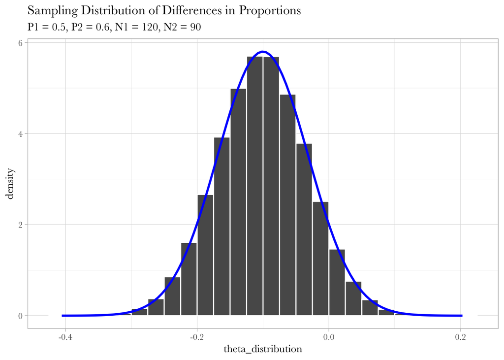

```r
tibble(theta_distribution) |>
  ggplot(aes(theta_distribution)) +
  geom_histogram(
    color = "white", boundary = 0.5, binwidth = 0.025,
    mapping = aes(y = after_stat(density))
  ) +
  labs(title = "Sampling Distribution of Differences in Proportions",
       subtitle= "P1 = 0.5, P2 = 0.6, N1 = 120, N2 = 90") +
  geom_function(fun = \(x) dnorm(x, mean = mean(theta_distribution), sd = sd(theta_distribution)), color = "blue", linewidth = 1.05)
```

## 6.1.8 Exercise

**Text of 6.1.8 Exercise Question**

*Comparison of proportions.*

A randomized experiment is performed within a survey. 1000 people are contacted. Half the people contacted are promised a $5 incentive to participate, and half are not promised an incentive. The result is a 50% response rate among the treated group and 40% response rate among the control group. Give an estimate and standard error of the difference in proportions.

```r
p1 <- 0.5
n1 <- 500
p2 <- 0.4
n2 <- 500

S <- 1e4
draws1 <- rbinom(S, size = n1, prob = p1)
proportions1 <- draws1 / n1
draws2 <- rbinom(S, size = n2, prob = p2)
proportions2 <- draws2 / n2
theta_distribution <- proportions1 - proportions2

# estimate of diff of proportions
mean(theta_distribution)
```

```
[1] 0.1003786
```

```r
# se of the difference in proportions
sd(theta_distribution)
```

```
[1] 0.0315371
```

## GSS Setup

```r
gss18 <- gss_get_yr(2018)
```

```
Fetching: https://gss.norc.org/documents/stata/2018_stata.zip
```

```r
d <- gss18 |>
  select(sex, attend, polviews) |>
  haven::zap_missing() |>
  mutate(sex = as_factor(sex)) |>
  haven::zap_labels() |>
  drop_na()

glimpse(d)
```

```
Rows: 2,235
Columns: 3
$ sex      <fct> male, male, female, male, female, female, male, female, male,…
$ attend   <dbl> 5, 2, 6, 8, 4, 7, 7, 0, 4, 5, 0, 3, 0, 7, 1, 0, 4, 5, 2, 7, 1…
$ polviews <dbl> 6, 5, 4, 7, 3, 4, 5, 4, 6, 4, 4, 3, 2, 5, 2, 6, 2, 4, 6, 6, 4…
```

## 6.2.1 Exercise

The variable `attend` asks respondents “How often do you attend religious services?” The answers are coded as follows:

- 0: Never
- 1: Less than once a year
- 2: About once or twice a year
- 3: Several times a year
- 4: About once a month
- 5: 2-3 times a month
- 6: Nearly every week
- 7: Every week
- 8: Several times a week

The variable `polviews` asks respondents to place themselves on a scale of political views from 1 to 7, with categories being:

- 1: Extremely liberal
- 2: Liberal
- 3: Slightly liberal
- 4: Moderate, middle of the road
- 5: Slightly conservative
- 6: Conservative
- 7: Extremely conservative

## 6.2.2 Exercise

**Text of 6.2.2 Exercise Question**

Repeat what we did in class with Steve, but compare the `weekly` variable to a new variable call `conservative`.

```r
d <- gss18 |>
  mutate(female = if_else(sex == 2, 1L, 0L),
         weekly = if_else(attend >= 7, 1L, 0L),
         conservative = if_else(polviews >= 5, 1L, 0L)) |>
  select(female, weekly, conservative) |>
  drop_na() |>
  mutate(sex = if_else(female == 1, "Female", "Male"))

glimpse(d$conservative)
```

```
 int [1:2235] 1 1 0 1 0 0 1 0 1 0 ...
```

## 6.2.3 Exercise

**Question**

Is the difference in proportions between `conservative` and `weekly` statistically significant?

```r
obs_diff <- mean(d$conservative) - mean(d$weekly)
d <- d |> mutate(attendance = if_else(weekly == 1, "Weekly", "LessThanWeekly"))

boot_dist <- d |>
  specify(conservative ~ attendance) |>
  generate(reps = 1000,
           type = "bootstrap") |>
  calculate(stat = "diff in means",
            order = c("Weekly", "LessThanWeekly"))

ci <- boot_dist |>
  get_confidence_interval(level = .95)
ci
```

```
# A tibble: 1 × 2
  lower_ci upper_ci
     <dbl>    <dbl>
1    0.149    0.246
```

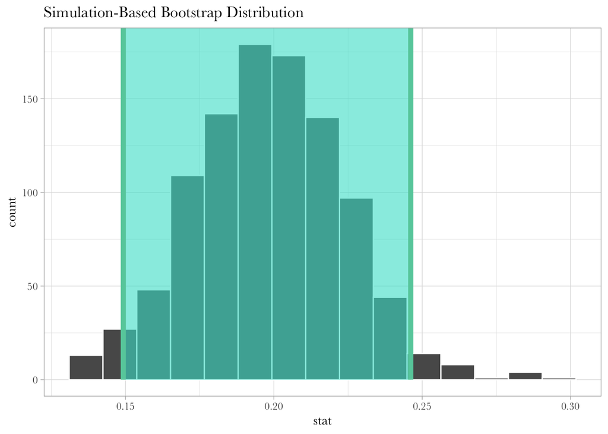

```r
boot_dist |>
  visualize() +
  shade_ci(ci)
```

## 6.2.4 Exercise

In sum: row percentages are the % that each each cell represents of the *row total*.  
Column percentages are the % that each cell represents of the *column total.*

This can get confusing. Note that the sum of all cells is far greater than 100. Rather, the sum of all the percentages in a row is 100, and the sum of all percentages in a column is 100. This is because these percentages are based on row/column totals, not the total sample.

The % in a cell is *not* the total number of cases in the sample that have both characteristics of row and column values. For a row percentage, the % in a cell is the proprotion of cases *from all cases **in that row*** with the particular column characteristic. For a column percentage, the % in a cell is the proportion of cases *from all cases **in that column*** with the particular row characteristic. Tricky!